# Risk Factor Analysis

## Outcome Variable

**Outcome Variable:** wast_rec90d

## Predictor Variables

**Intervention Variable:** single

**Adjustment Set:**

- arm
- W_mage
- meducyrs
- feducyrs
- W_mhtcm
- W_mwtkg
- W_mbmi
- delta_W_mage
- delta_meducyrs
- delta_feducyrs
- delta_W_mhtcm
- delta_W_mwtkg
- delta_W_mbmi

## Stratifying Variables

The analysis was stratified on these variable(s):

- agecat
- studyid
- country

## Data Summary

| agecat | studyid | country | single | wast_rec90d | n_cell | n |
| --- | --- | --- | --- | --- | --- | --- |
| 0-24 months | COHORTS | GUATEMALA | 0 | 0 | 179 | 353 |
| 0-24 months | COHORTS | GUATEMALA | 0 | 1 | 150 | 353 |
| 0-24 months | COHORTS | GUATEMALA | 1 | 0 | 18 | 353 |
| 0-24 months | COHORTS | GUATEMALA | 1 | 1 | 6 | 353 |
| 0-24 months | COHORTS | INDIA | 0 | 0 | 1499 | 1962 |
| 0-24 months | COHORTS | INDIA | 0 | 1 | 459 | 1962 |
| 0-24 months | COHORTS | INDIA | 1 | 0 | 3 | 1962 |
| 0-24 months | COHORTS | INDIA | 1 | 1 | 1 | 1962 |
| 0-24 months | COHORTS | PHILIPPINES | 0 | 0 | 628 | 1661 |
| 0-24 months | COHORTS | PHILIPPINES | 0 | 1 | 980 | 1661 |
| 0-24 months | COHORTS | PHILIPPINES | 1 | 0 | 28 | 1661 |
| 0-24 months | COHORTS | PHILIPPINES | 1 | 1 | 25 | 1661 |
| 0-24 months | Guatemala BSC | GUATEMALA | 0 | 0 | 18 | 37 |
| 0-24 months | Guatemala BSC | GUATEMALA | 0 | 1 | 16 | 37 |
| 0-24 months | Guatemala BSC | GUATEMALA | 1 | 0 | 2 | 37 |
| 0-24 months | Guatemala BSC | GUATEMALA | 1 | 1 | 1 | 37 |
| 0-24 months | JiVitA-4 | BANGLADESH | 0 | 0 | 1529 | 2062 |
| 0-24 months | JiVitA-4 | BANGLADESH | 0 | 1 | 532 | 2062 |
| 0-24 months | JiVitA-4 | BANGLADESH | 1 | 0 | 1 | 2062 |
| 0-24 months | JiVitA-4 | BANGLADESH | 1 | 1 | 0 | 2062 |
| 0-24 months | MAL-ED | BANGLADESH | 0 | 0 | 44 | 124 |
| 0-24 months | MAL-ED | BANGLADESH | 0 | 1 | 80 | 124 |
| 0-24 months | MAL-ED | BANGLADESH | 1 | 0 | 0 | 124 |
| 0-24 months | MAL-ED | BANGLADESH | 1 | 1 | 0 | 124 |
| 0-24 months | MAL-ED | BRAZIL | 0 | 0 | 5 | 24 |
| 0-24 months | MAL-ED | BRAZIL | 0 | 1 | 13 | 24 |
| 0-24 months | MAL-ED | BRAZIL | 1 | 0 | 1 | 24 |
| 0-24 months | MAL-ED | BRAZIL | 1 | 1 | 5 | 24 |
| 0-24 months | MAL-ED | INDIA | 0 | 0 | 71 | 180 |
| 0-24 months | MAL-ED | INDIA | 0 | 1 | 109 | 180 |

[output cut: 150 more lines]

The following strata were considered:

- agecat: 0-24 months, studyid: COHORTS, country: GUATEMALA
- agecat: 0-24 months, studyid: COHORTS, country: INDIA
- agecat: 0-24 months, studyid: COHORTS, country: PHILIPPINES
- agecat: 0-24 months, studyid: Guatemala BSC, country: GUATEMALA
- agecat: 0-24 months, studyid: JiVitA-4, country: BANGLADESH
- agecat: 0-24 months, studyid: MAL-ED, country: BANGLADESH
- agecat: 0-24 months, studyid: MAL-ED, country: BRAZIL
- agecat: 0-24 months, studyid: MAL-ED, country: INDIA
- agecat: 0-24 months, studyid: MAL-ED, country: NEPAL
- agecat: 0-24 months, studyid: MAL-ED, country: PERU
- agecat: 0-24 months, studyid: MAL-ED, country: SOUTH AFRICA
- agecat: 0-24 months, studyid: MAL-ED, country: TANZANIA, UNITED REPUBLIC OF
- agecat: 0-24 months, studyid: PROBIT, country: BELARUS
- agecat: 0-24 months, studyid: TanzaniaChild2, country: TANZANIA, UNITED REPUBLIC OF
- agecat: 0-24 months, studyid: ZVITAMBO, country: ZIMBABWE
- agecat: 0-6 months, studyid: COHORTS, country: GUATEMALA
- agecat: 0-6 months, studyid: COHORTS, country: INDIA
- agecat: 0-6 months, studyid: COHORTS, country: PHILIPPINES
- agecat: 0-6 months, studyid: Guatemala BSC, country: GUATEMALA
- agecat: 0-6 months, studyid: JiVitA-4, country: BANGLADESH
- agecat: 0-6 months, studyid: MAL-ED, country: BANGLADESH
- agecat: 0-6 months, studyid: MAL-ED, country: BRAZIL
- agecat: 0-6 months, studyid: MAL-ED, country: INDIA
- agecat: 0-6 months, studyid: MAL-ED, country: NEPAL
- agecat: 0-6 months, studyid: MAL-ED, country: PERU
- agecat: 0-6 months, studyid: MAL-ED, country: SOUTH AFRICA
- agecat: 0-6 months, studyid: MAL-ED, country: TANZANIA, UNITED REPUBLIC OF
- agecat: 0-6 months, studyid: PROBIT, country: BELARUS
- agecat: 0-6 months, studyid: TanzaniaChild2, country: TANZANIA, UNITED REPUBLIC OF
- agecat: 0-6 months, studyid: ZVITAMBO, country: ZIMBABWE
- agecat: 6-24 months, studyid: COHORTS, country: GUATEMALA
- agecat: 6-24 months, studyid: COHORTS, country: INDIA
- agecat: 6-24 months, studyid: COHORTS, country: PHILIPPINES
- agecat: 6-24 months, studyid: Guatemala BSC, country: GUATEMALA
- agecat: 6-24 months, studyid: JiVitA-4, country: BANGLADESH
- agecat: 6-24 months, studyid: MAL-ED, country: BANGLADESH
- agecat: 6-24 months, studyid: MAL-ED, country: BRAZIL
- agecat: 6-24 months, studyid: MAL-ED, country: INDIA
- agecat: 6-24 months, studyid: MAL-ED, country: NEPAL
- agecat: 6-24 months, studyid: MAL-ED, country: PERU
- agecat: 6-24 months, studyid: MAL-ED, country: SOUTH AFRICA
- agecat: 6-24 months, studyid: MAL-ED, country: TANZANIA, UNITED REPUBLIC OF
- agecat: 6-24 months, studyid: PROBIT, country: BELARUS
- agecat: 6-24 months, studyid: TanzaniaChild2, country: TANZANIA, UNITED REPUBLIC OF
- agecat: 6-24 months, studyid: ZVITAMBO, country: ZIMBABWE

### Dropped Strata

Some strata were dropped due to rare outcomes:

- agecat: 0-24 months, studyid: COHORTS, country: INDIA
- agecat: 0-24 months, studyid: Guatemala BSC, country: GUATEMALA
- agecat: 0-24 months, studyid: JiVitA-4, country: BANGLADESH
- agecat: 0-24 months, studyid: MAL-ED, country: BANGLADESH
- agecat: 0-24 months, studyid: MAL-ED, country: BRAZIL
- agecat: 0-24 months, studyid: MAL-ED, country: INDIA
- agecat: 0-24 months, studyid: MAL-ED, country: NEPAL
- agecat: 0-24 months, studyid: MAL-ED, country: PERU
- agecat: 0-24 months, studyid: MAL-ED, country: TANZANIA, UNITED REPUBLIC OF
- agecat: 0-6 months, studyid: COHORTS, country: GUATEMALA
- agecat: 0-6 months, studyid: COHORTS, country: INDIA
- agecat: 0-6 months, studyid: Guatemala BSC, country: GUATEMALA
- agecat: 0-6 months, studyid: JiVitA-4, country: BANGLADESH
- agecat: 0-6 months, studyid: MAL-ED, country: BANGLADESH
- agecat: 0-6 months, studyid: MAL-ED, country: BRAZIL
- agecat: 0-6 months, studyid: MAL-ED, country: INDIA
- agecat: 0-6 months, studyid: MAL-ED, country: NEPAL
- agecat: 0-6 months, studyid: MAL-ED, country: PERU
- agecat: 0-6 months, studyid: MAL-ED, country: SOUTH AFRICA
- agecat: 0-6 months, studyid: MAL-ED, country: TANZANIA, UNITED REPUBLIC OF
- agecat: 6-24 months, studyid: COHORTS, country: GUATEMALA
- agecat: 6-24 months, studyid: COHORTS, country: INDIA
- agecat: 6-24 months, studyid: Guatemala BSC, country: GUATEMALA
- agecat: 6-24 months, studyid: JiVitA-4, country: BANGLADESH
- agecat: 6-24 months, studyid: MAL-ED, country: BANGLADESH
- agecat: 6-24 months, studyid: MAL-ED, country: BRAZIL
- agecat: 6-24 months, studyid: MAL-ED, country: INDIA
- agecat: 6-24 months, studyid: MAL-ED, country: NEPAL
- agecat: 6-24 months, studyid: MAL-ED, country: PERU
- agecat: 6-24 months, studyid: MAL-ED, country: SOUTH AFRICA
- agecat: 6-24 months, studyid: MAL-ED, country: TANZANIA, UNITED REPUBLIC OF
- agecat: 6-24 months, studyid: PROBIT, country: BELARUS

## Methods Detail

We’re interested in the causal parameters $E[Y_a]$ for all values of $a \in \mathcal{A}$. These parameters represent the mean outcome if, possibly contrary to fact, we intervened to set all units to have $A=a$. Under the randomization and positivity assumptions, these are identified by the statistical parameters $\psi_a=E_W[E_{Y|A,W}(Y|A=a,W)]$. In addition, we’re interested in the mean of $Y$, $E[Y]$ under no intervention (the observed mean). We will estimate these parameters by using SuperLearner to fit the relevant likelihood factors – $E_{Y|A,W}(Y|A=a,W)$ and $p(A=a|W)$, and then updating our likelihood fit using a joint TMLE.

For unadjusted analyses ($W=\{\}$), initial likelihoods were estimated using Lrnr_glm to estimate the simple $E(Y|A)$ and Lrnr_mean to estimate $p(A)$. For adjusted analyses, a small library containing Lrnr_glmnet, Lrnr_xgboost, and Lrnr_mean was used.

Having estimated these parameters, we will then use the delta method to estimate relative risks and attributable risks relative to a prespecified baseline level of $A$.

# Results Detail

## Results Plots

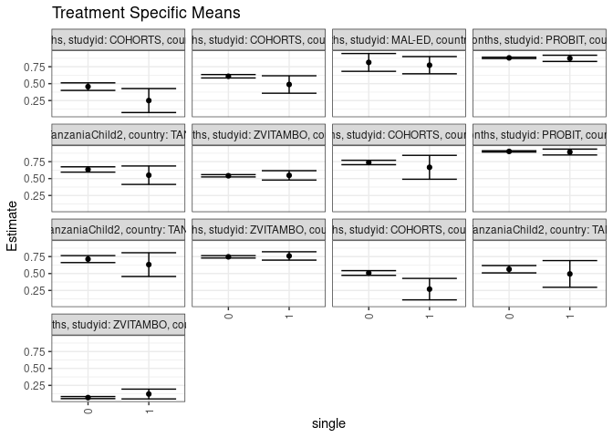

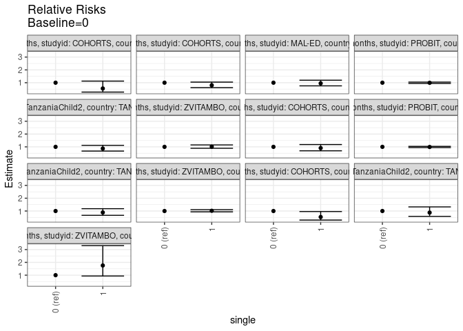

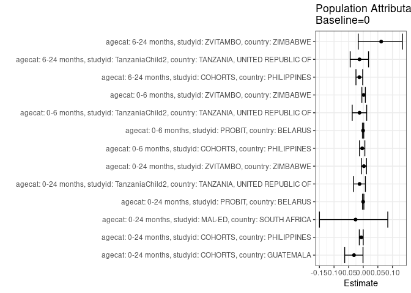

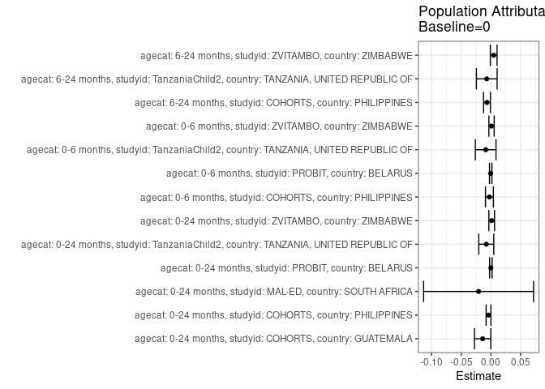

## Results Table

### Parameter: TSM

| agecat | studyid | country | intervention_level | baseline_level | estimate | ci_lower | ci_upper |
| --- | --- | --- | --- | --- | --- | --- | --- |
| 0-24 months | COHORTS | GUATEMALA | 0 | NA | 0.4559271 | 0.4002153 | 0.5116388 |
| 0-24 months | COHORTS | GUATEMALA | 1 | NA | 0.2500000 | 0.0728958 | 0.4271042 |
| 0-24 months | COHORTS | PHILIPPINES | 0 | NA | 0.6091552 | 0.5838268 | 0.6344836 |
| 0-24 months | COHORTS | PHILIPPINES | 1 | NA | 0.4874738 | 0.3583050 | 0.6166427 |
| 0-24 months | MAL-ED | SOUTH AFRICA | 0 | NA | 0.8139535 | 0.6823222 | 0.9455848 |
| 0-24 months | MAL-ED | SOUTH AFRICA | 1 | NA | 0.7727273 | 0.6455316 | 0.8999229 |
| 0-24 months | PROBIT | BELARUS | 0 | NA | 0.8808777 | 0.8711653 | 0.8905901 |
| 0-24 months | PROBIT | BELARUS | 1 | NA | 0.8738648 | 0.8279492 | 0.9197804 |
| 0-24 months | TanzaniaChild2 | TANZANIA, UNITED REPUBLIC OF | 0 | NA | 0.6346643 | 0.5952790 | 0.6740496 |
| 0-24 months | TanzaniaChild2 | TANZANIA, UNITED REPUBLIC OF | 1 | NA | 0.5498254 | 0.4135094 | 0.6861413 |
| 0-24 months | ZVITAMBO | ZIMBABWE | 0 | NA | 0.5415913 | 0.5245380 | 0.5586445 |
| 0-24 months | ZVITAMBO | ZIMBABWE | 1 | NA | 0.5475214 | 0.4785281 | 0.6165147 |
| 0-6 months | COHORTS | PHILIPPINES | 0 | NA | 0.7380282 | 0.7055710 | 0.7704853 |
| 0-6 months | COHORTS | PHILIPPINES | 1 | NA | 0.6666667 | 0.4900832 | 0.8432501 |
| 0-6 months | PROBIT | BELARUS | 0 | NA | 0.9013165 | 0.8920966 | 0.9105363 |
| 0-6 months | PROBIT | BELARUS | 1 | NA | 0.8921813 | 0.8487527 | 0.9356099 |
| 0-6 months | TanzaniaChild2 | TANZANIA, UNITED REPUBLIC OF | 0 | NA | 0.7130861 | 0.6615624 | 0.7646098 |
| 0-6 months | TanzaniaChild2 | TANZANIA, UNITED REPUBLIC OF | 1 | NA | 0.6317858 | 0.4562042 | 0.8073674 |
| 0-6 months | ZVITAMBO | ZIMBABWE | 0 | NA | 0.7465604 | 0.7290188 | 0.7641020 |
| 0-6 months | ZVITAMBO | ZIMBABWE | 1 | NA | 0.7596036 | 0.6979767 | 0.8212306 |
| 6-24 months | COHORTS | PHILIPPINES | 0 | NA | 0.5077951 | 0.4732557 | 0.5423345 |
| 6-24 months | COHORTS | PHILIPPINES | 1 | NA | 0.2692308 | 0.1105079 | 0.4279537 |
| 6-24 months | TanzaniaChild2 | TANZANIA, UNITED REPUBLIC OF | 0 | NA | 0.5635472 | 0.5090381 | 0.6180563 |
| 6-24 months | TanzaniaChild2 | TANZANIA, UNITED REPUBLIC OF | 1 | NA | 0.4939294 | 0.2966967 | 0.6911622 |
| 6-24 months | ZVITAMBO | ZIMBABWE | 0 | NA | 0.0695548 | 0.0538912 | 0.0852185 |
| 6-24 months | ZVITAMBO | ZIMBABWE | 1 | NA | 0.1222582 | 0.0501719 | 0.1943445 |

### Parameter: E(Y)

| agecat | studyid | country | intervention_level | baseline_level | estimate | ci_lower | ci_upper |
| --- | --- | --- | --- | --- | --- | --- | --- |
| 0-24 months | COHORTS | GUATEMALA | NA | NA | 0.4419263 | 0.3882796 | 0.4955731 |
| 0-24 months | COHORTS | PHILIPPINES | NA | NA | 0.6050572 | 0.5803571 | 0.6297573 |
| 0-24 months | MAL-ED | SOUTH AFRICA | NA | NA | 0.7931034 | 0.7014938 | 0.8847131 |
| 0-24 months | PROBIT | BELARUS | NA | NA | 0.8806715 | 0.8711794 | 0.8901636 |
| 0-24 months | TanzaniaChild2 | TANZANIA, UNITED REPUBLIC OF | NA | NA | 0.6267606 | 0.5890263 | 0.6644948 |
| 0-24 months | ZVITAMBO | ZIMBABWE | NA | NA | 0.5428254 | 0.5263835 | 0.5592672 |
| 0-6 months | COHORTS | PHILIPPINES | NA | NA | 0.7354138 | 0.7034648 | 0.7673628 |
| 0-6 months | PROBIT | BELARUS | NA | NA | 0.9008671 | 0.8918443 | 0.9098900 |
| 0-6 months | TanzaniaChild2 | TANZANIA, UNITED REPUBLIC OF | NA | NA | 0.7041420 | 0.6547600 | 0.7535240 |
| 0-6 months | ZVITAMBO | ZIMBABWE | NA | NA | 0.7475030 | 0.7304953 | 0.7645107 |
| 6-24 months | COHORTS | PHILIPPINES | NA | NA | 0.5010823 | 0.4670433 | 0.5351212 |
| 6-24 months | TanzaniaChild2 | TANZANIA, UNITED REPUBLIC OF | NA | NA | 0.5564516 | 0.5041613 | 0.6087419 |
| 6-24 months | ZVITAMBO | ZIMBABWE | NA | NA | 0.0741080 | 0.0586494 | 0.0895665 |

### Parameter: RR

| agecat | studyid | country | intervention_level | baseline_level | estimate | ci_lower | ci_upper |
| --- | --- | --- | --- | --- | --- | --- | --- |
| 0-24 months | COHORTS | GUATEMALA | 0 | 0 | 1.0000000 | 1.0000000 | 1.0000000 |
| 0-24 months | COHORTS | GUATEMALA | 1 | 0 | 0.5483333 | 0.2671990 | 1.1252640 |
| 0-24 months | COHORTS | PHILIPPINES | 0 | 0 | 1.0000000 | 1.0000000 | 1.0000000 |
| 0-24 months | COHORTS | PHILIPPINES | 1 | 0 | 0.8002457 | 0.6119864 | 1.0464174 |
| 0-24 months | MAL-ED | SOUTH AFRICA | 0 | 0 | 1.0000000 | 1.0000000 | 1.0000000 |
| 0-24 months | MAL-ED | SOUTH AFRICA | 1 | 0 | 0.9493506 | 0.7536894 | 1.1958064 |
| 0-24 months | PROBIT | BELARUS | 0 | 0 | 1.0000000 | 1.0000000 | 1.0000000 |
| 0-24 months | PROBIT | BELARUS | 1 | 0 | 0.9920388 | 0.9401886 | 1.0467484 |
| 0-24 months | TanzaniaChild2 | TANZANIA, UNITED REPUBLIC OF | 0 | 0 | 1.0000000 | 1.0000000 | 1.0000000 |
| 0-24 months | TanzaniaChild2 | TANZANIA, UNITED REPUBLIC OF | 1 | 0 | 0.8663247 | 0.6709668 | 1.1185627 |
| 0-24 months | ZVITAMBO | ZIMBABWE | 0 | 0 | 1.0000000 | 1.0000000 | 1.0000000 |
| 0-24 months | ZVITAMBO | ZIMBABWE | 1 | 0 | 1.0109495 | 0.8880508 | 1.1508563 |
| 0-6 months | COHORTS | PHILIPPINES | 0 | 0 | 1.0000000 | 1.0000000 | 1.0000000 |
| 0-6 months | COHORTS | PHILIPPINES | 1 | 0 | 0.9033079 | 0.6906013 | 1.1815285 |
| 0-6 months | PROBIT | BELARUS | 0 | 0 | 1.0000000 | 1.0000000 | 1.0000000 |
| 0-6 months | PROBIT | BELARUS | 1 | 0 | 0.9898646 | 0.9418476 | 1.0403297 |
| 0-6 months | TanzaniaChild2 | TANZANIA, UNITED REPUBLIC OF | 0 | 0 | 1.0000000 | 1.0000000 | 1.0000000 |
| 0-6 months | TanzaniaChild2 | TANZANIA, UNITED REPUBLIC OF | 1 | 0 | 0.8859880 | 0.6646493 | 1.1810362 |
| 0-6 months | ZVITAMBO | ZIMBABWE | 0 | 0 | 1.0000000 | 1.0000000 | 1.0000000 |
| 0-6 months | ZVITAMBO | ZIMBABWE | 1 | 0 | 1.0174711 | 0.9358239 | 1.1062418 |
| 6-24 months | COHORTS | PHILIPPINES | 0 | 0 | 1.0000000 | 1.0000000 | 1.0000000 |
| 6-24 months | COHORTS | PHILIPPINES | 1 | 0 | 0.5301957 | 0.2928894 | 0.9597734 |
| 6-24 months | TanzaniaChild2 | TANZANIA, UNITED REPUBLIC OF | 0 | 0 | 1.0000000 | 1.0000000 | 1.0000000 |
| 6-24 months | TanzaniaChild2 | TANZANIA, UNITED REPUBLIC OF | 1 | 0 | 0.8764651 | 0.5812984 | 1.3215088 |
| 6-24 months | ZVITAMBO | ZIMBABWE | 0 | 0 | 1.0000000 | 1.0000000 | 1.0000000 |
| 6-24 months | ZVITAMBO | ZIMBABWE | 1 | 0 | 1.7577238 | 0.9349594 | 3.3045210 |

### Parameter: PAR

| agecat | studyid | country | intervention_level | baseline_level | estimate | ci_lower | ci_upper |
| --- | --- | --- | --- | --- | --- | --- | --- |
| 0-24 months | COHORTS | GUATEMALA | 0 | NA | -0.0140007 | -0.0277753 | -0.0002261 |
| 0-24 months | COHORTS | PHILIPPINES | 0 | NA | -0.0040980 | -0.0081579 | -0.0000381 |
| 0-24 months | MAL-ED | SOUTH AFRICA | 0 | NA | -0.0208500 | -0.1134431 | 0.0717430 |
| 0-24 months | PROBIT | BELARUS | 0 | NA | -0.0002062 | -0.0023100 | 0.0018976 |
| 0-24 months | TanzaniaChild2 | TANZANIA, UNITED REPUBLIC OF | 0 | NA | -0.0079037 | -0.0205086 | 0.0047011 |
| 0-24 months | ZVITAMBO | ZIMBABWE | 0 | NA | 0.0012341 | -0.0035475 | 0.0060157 |
| 0-6 months | COHORTS | PHILIPPINES | 0 | NA | -0.0026143 | -0.0092776 | 0.0040489 |
| 0-6 months | PROBIT | BELARUS | 0 | NA | -0.0004493 | -0.0024935 | 0.0015948 |
| 0-6 months | TanzaniaChild2 | TANZANIA, UNITED REPUBLIC OF | 0 | NA | -0.0089441 | -0.0263529 | 0.0084647 |
| 0-6 months | ZVITAMBO | ZIMBABWE | 0 | NA | 0.0009426 | -0.0035241 | 0.0054094 |
| 6-24 months | COHORTS | PHILIPPINES | 0 | NA | -0.0067128 | -0.0124377 | -0.0009880 |
| 6-24 months | TanzaniaChild2 | TANZANIA, UNITED REPUBLIC OF | 0 | NA | -0.0070956 | -0.0245370 | 0.0103458 |
| 6-24 months | ZVITAMBO | ZIMBABWE | 0 | NA | 0.0045531 | -0.0011041 | 0.0102103 |

### Parameter: PAF

| agecat | studyid | country | intervention_level | baseline_level | estimate | ci_lower | ci_upper |
| --- | --- | --- | --- | --- | --- | --- | --- |
| 0-24 months | COHORTS | GUATEMALA | 0 | NA | -0.0316811 | -0.0634737 | -0.0008389 |
| 0-24 months | COHORTS | PHILIPPINES | 0 | NA | -0.0067729 | -0.0134903 | -0.0001001 |
| 0-24 months | MAL-ED | SOUTH AFRICA | 0 | NA | -0.0262892 | -0.1499083 | 0.0840405 |
| 0-24 months | PROBIT | BELARUS | 0 | NA | -0.0002341 | -0.0026258 | 0.0021519 |
| 0-24 months | TanzaniaChild2 | TANZANIA, UNITED REPUBLIC OF | 0 | NA | -0.0126105 | -0.0329629 | 0.0073409 |
| 0-24 months | ZVITAMBO | ZIMBABWE | 0 | NA | 0.0022735 | -0.0065735 | 0.0110427 |
| 0-6 months | COHORTS | PHILIPPINES | 0 | NA | -0.0035549 | -0.0126621 | 0.0054704 |
| 0-6 months | PROBIT | BELARUS | 0 | NA | -0.0004988 | -0.0027705 | 0.0017678 |
| 0-6 months | TanzaniaChild2 | TANZANIA, UNITED REPUBLIC OF | 0 | NA | -0.0127021 | -0.0377923 | 0.0117814 |
| 0-6 months | ZVITAMBO | ZIMBABWE | 0 | NA | 0.0012610 | -0.0047322 | 0.0072185 |
| 6-24 months | COHORTS | PHILIPPINES | 0 | NA | -0.0133967 | -0.0249192 | -0.0020037 |
| 6-24 months | TanzaniaChild2 | TANZANIA, UNITED REPUBLIC OF | 0 | NA | -0.0127515 | -0.0446547 | 0.0181774 |
| 6-24 months | ZVITAMBO | ZIMBABWE | 0 | NA | 0.0614390 | -0.0172145 | 0.1340108 |